# A Sequence Analysis of Population Change

## Stage 1 - Sequence Creation

Our data is currently presented in continuous form, i.e. containing values that can take on any value within a given range. However, Sequence Analysis requires categorical data. Our first task therefore requires us to convert our annual percentage change data into categories that represent the different order and magnitude of change. This involves creating a series of boundaries.

```r
# Define the years for column naming
years <- 1990:2022

# Function to categorize percentage changes
transform_pct_columns <- function(x) {
  case_when(
    x <= -3 ~ 'High Decline',
    x > -3 & x <= -1.5 ~ 'Decline',
    x > -1.5 & x <= -0.3 ~ 'Moderate Decline',
    x > -0.3 & x < 0.3 ~ 'Stable',
    x >= 0.3 & x < 1.5 ~ 'Moderate Growth',
    x >= 1.5 & x < 3 ~ 'Growth',
    x >= 3 ~ 'High Growth',
    TRUE ~ as.character(x)
  )
}

# Loop through each percentage change column and apply case_when
# searches for column names in the Decline dataframe (names(Decline)) that start with "pct_". The value = TRUE argument returns the actual names of the columns that match the pattern.
for (col in grep("^pct_", names(Decline), value = TRUE)) {
  new_col_name <- paste0(sub("pct_", "", col))

  Decline[[new_col_name]] <- transform_pct_columns(Decline[[col]])
}

# View the resulting Decline dataframe
head(Decline)
```

```
##      X State County_FIP pct_1990_to_1991 pct_1991_to_1992 pct_1992_to_1993
## 1 3121    AK         60             3.03             8.18             8.34
## 2 3122    AK         68             6.38             4.63            -3.85
## 3 3124    AK        100             5.86            -2.72             1.47
## 4 3127    AK        130             1.28             2.68             0.43
## 5 3128    AK        150             3.44             1.03             1.53
## 6 3134    AK        220             2.55             1.75             2.72
##   pct_1993_to_1994 pct_1994_to_1995 pct_1995_to_1996 pct_1996_to_1997
## 1           -26.25            -7.44             7.08             6.37
## 2             5.53            -0.41             5.46            -1.61
## 3             4.66            -0.35             0.22             1.99
## 4             0.77             0.63             1.16            -1.24
## 5             3.11            -1.08            -0.38            -1.76
## 6            -2.18            -1.39            -1.23             1.02
##   pct_1997_to_1998 pct_1998_to_1999 pct_1999_to_2000 pct_2000_to_2001
```

[output cut: 104 more lines]

Next, we define our sequence alphabet and create our sequence object which contains the full population change trajectories for each US county.

```r
#set the sequence alphabet
labels <- c("High Decline", "Decline", "Moderate Decline", "Stable","Moderate Growth", "Growth", "High Growth")
scode <- c("HDE", "MDE","LDE", "ST", "LGR", "MGR", "HGR")

#create sequence object
seq_all <- seqdef(Decline, 36:67, alphabet = labels, states = scode, labels = labels, xtstep = 6)
```

```
##  [>] state coding:
```

```
##        [alphabet]       [label]  [long label]
```

```
##      1  High Decline     HDE      High Decline
```

```
##      2  Decline          MDE      Decline
```

```
##      3  Moderate Decline LDE      Moderate Decline
```

```
##      4  Stable           ST       Stable
```

```
##      5  Moderate Growth  LGR      Moderate Growth
```

```
##      6  Growth           MGR      Growth
```

```
##      7  High Growth      HGR      High Growth
```

```
##  [>] 1073 sequences in the data set
```

```
##  [>] min/max sequence length: 32/32
```

```r
#preliminary plots - state distribution and state index plots
#first change the colour scheme
cpal(seq_all) <- c("#045a8d", "#2b8cbe", "#bdc9e1","#FFFFFF", "#fcae91","#fb6a4a", "#de2d26")
```

Already at this point we can summarise the population trajectories of US counties by visualising their sequences of population change.

Distribution plots (Seqdplot) display the frequency of a given state for each year. These plots examine the data from a vertical perspective i.e. looking at individual years across areas, rather than at individual areas over time. State distribution plots reveal predominant states in each year and changes in their prevalence.

Index plots (Seqiplot) provide a visual representation of how individual areas moves between states. Put simply, they represent the time series of our categorical states of population change. Here, each line in these plots represents an area. Time is displayed horizontally and colours encode different states.

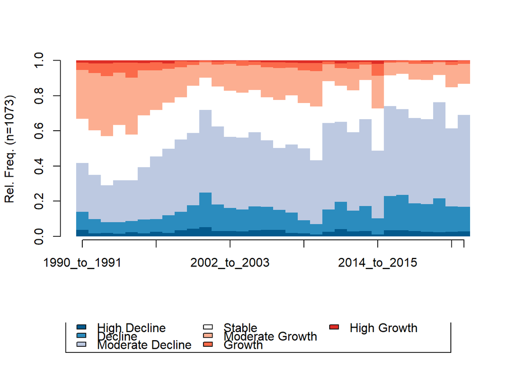

```r
windows()
seqdplot(seq_all, with.legend = T, border = NA, tick.last = TRUE)
```

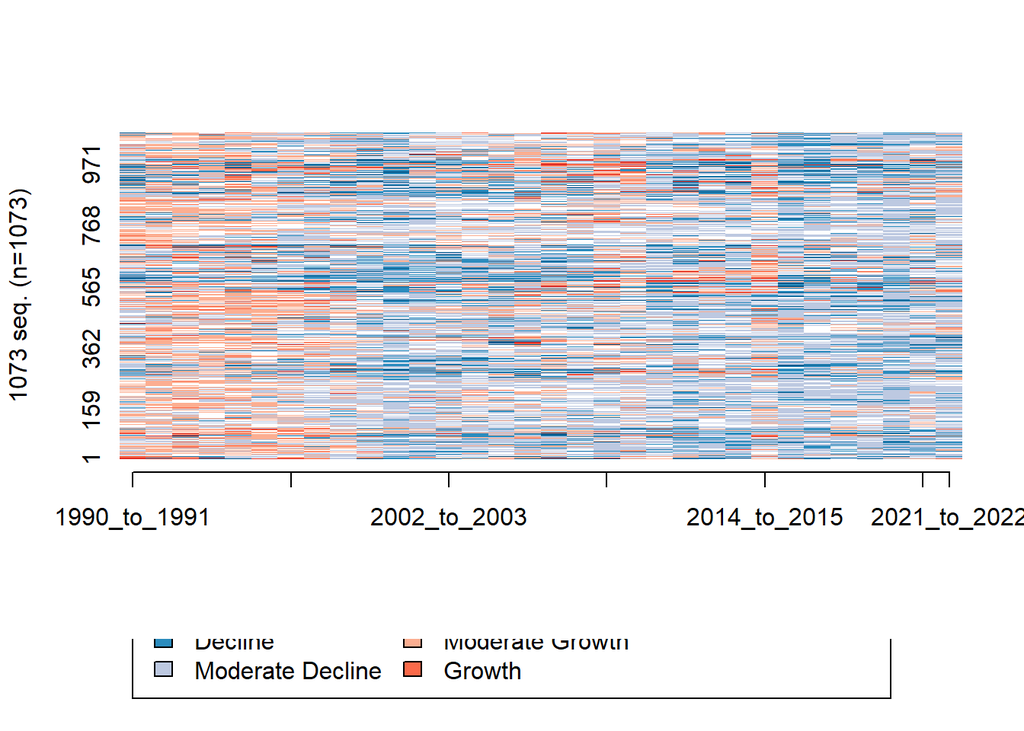

```r
seqIplot(seq_all, with.legend = T, border = NA, tick.last = TRUE)
```

What do these plots tell us about the general trend of population change in areas of population decline? Remember, all areas included in this specific exercise have experienced an absolute decline in their populations from 1990 to 2022 - meaning that their population size is lower in 2022 than in 1990. It is very likely that you will include these plots in your final report!

## Stage 2 - Optimal Matching

The next stage involves comparing sequences of population change. We do this by measuring the extent of dissimilarity between individual population change sequences. To this end, we use a sequence analysis technique to compute *distances* between sequences as a function of the number of transformations required to make sequences identical.

Two sets of operations are generally used: (1) insertion/deletion (known as indel) and (2) substitution operations. Both of these operations represent the cost of transforming one sequence into another. Intuitively, the idea is to estimate the cost of transforming one sequence into another so that the greater the cost to make two sequences identical, the greater the dissimilarity and vice versa.

Indel operations involve the addition or removal of an element within the sequence and substitution operations are the replacement of one element for another. Each of these operations is assigned a cost, and the distance between two sequences is defined as the minimum cost to transform one sequence to another (Abbott and Tsay 2000). By default, indel costs are set to 1. To illustrate indel operations, let’s consider an example of sequences of annual population change for three areas during 2000 and 2003. The sequences are identical, except for 2003. In this case, indel operations involve the cost of transforming the status stable in the sequence for area 1 to high decline in the sequence for area 2, and thus this operation would return a cost is 2. Why 2? It is 2 because you would need to delete stable and add high decline. Now, let’s try the cost of transforming the status stable in the sequence for area 1 to the status in the sequence for area 3 using indel operations. What is the cost? The answer is 1 because we only need to delete stable to make it identical.

Area 2000 2001 2002 2003 1 decline decline decline stable 2 decline decline decline high decline 3 decline decline decline -

Substitution operations represent transition costs; that is, the cost for substituting each state with another. We derive the costs of our substitutions using a data-driven approach. Here, substitution costs are empirically derived from transition rates between states. The cost of substitution is inversely related to the frequency of observed transitions within the data. This means that infrequent transitions between states have a higher substitution cost. For example, as we will see, transitions to distant states (eg high decline to high growth) are rarer than from transitions to nearby states (eg high decline to moderate decline) in US counties. This makes sense, as we expect gradual changes in population along a given trajectory if they were to occur due to natural causes.

By definition, transition rates vary between 0 and 1, with zero indicating no probability of a transition between states occurring. One indicates a 100% probability of a transition taking place.

```r
seq.trate<-seqtrate(seq_all)
```

```
##  [>] computing transition probabilities for states HDE/MDE/LDE/ST/LGR/MGR/HGR ...
```

```r
seq.trate
```

```
##             [-> HDE]   [-> MDE]  [-> LDE]   [-> ST]   [-> LGR]   [-> MGR]
## [HDE ->] 0.193617021 0.27127660 0.2404255 0.1010638 0.09787234 0.05638298
## [MDE ->] 0.064890205 0.30643967 0.3858870 0.1208981 0.08684925 0.02566000
## [LDE ->] 0.017336664 0.12135665 0.5194186 0.2157620 0.10538269 0.01627678
## [ST ->]  0.009002343 0.05820693 0.3774818 0.3533111 0.17906030 0.01948452
## [LGR ->] 0.015998562 0.06291569 0.2667625 0.2768290 0.31296063 0.05410750
## [MGR ->] 0.046860356 0.12933458 0.2014995 0.1387067 0.28959700 0.15276476
## [HGR ->] 0.136645963 0.10869565 0.1863354 0.1211180 0.15217391 0.14906832
##             [-> HGR]
## [HDE ->] 0.039361702
## [MDE ->] 0.009375771
## [LDE ->] 0.004466652
## [ST ->]  0.003452954
## [LGR ->] 0.010426029
## [MGR ->] 0.041237113
## [HGR ->] 0.145962733
```

The transition rate between state 𝑖 and state 𝑗 is the probability of observing state 𝑗 at time 𝑡+1 given that the state 𝑖 is observed at time 𝑡 for 𝑖 ≠ 𝑗. The substitution cost between states 𝑖 and 𝑗 is computed as:

2 −𝑝(𝑖|𝑗) −𝑝(𝑗|𝑖)

where 𝑝(𝑖|𝑗) is the transition rate between state 𝑖 and 𝑗.

```r
#calculate substitution costs based on transition rates observed in the data and a 1 indel cost
submat <- seqsubm(seq_all, method = "TRATE")
```

```
##  [>] creating substitution-cost matrix using transition rates ...
```

```
##  [>] computing transition probabilities for states HDE/MDE/LDE/ST/LGR/MGR/HGR ...
```

```r
submat
```

```
##          HDE      MDE      LDE       ST      LGR      MGR      HGR
## HDE 0.000000 1.663833 1.742238 1.889934 1.886129 1.896757 1.823992
## MDE 1.663833 0.000000 1.492756 1.820895 1.850235 1.845005 1.881929
## LDE 1.742238 1.492756 0.000000 1.406756 1.627855 1.782224 1.809198
## ST  1.889934 1.820895 1.406756 0.000000 1.544111 1.841809 1.875429
## LGR 1.886129 1.850235 1.627855 1.544111 0.000000 1.656296 1.837400
## MGR 1.896757 1.845005 1.782224 1.841809 1.656296 0.000000 1.809695
## HGR 1.823992 1.881929 1.809198 1.875429 1.837400 1.809695 0.000000
```

Next we focus on the most important component of sequence analysis; that is, the calculation of dissimilarity. Recall our aim is to identify representative trajectories of population change. To this end, we need a way to measure how similar or different sequences are. Above, we described that we can use indel and substitution operations to measure the dissimilarity (or costs between individual sequences).The code chunk below implements a matching based on indel and substitution operations. The algorithm takes an individual sequence and compares it with all of the sequences in the dataset (representing every US county), and identifies the sequence with the minimum cost i.e. the most similar sequence. The result of this computing intensive process is a distance matrix encoding the similarity or dissimilarity between individual sequences.

In our sequence analysis we use the Dynamic Hamming Distances (DHD) method to achieve this. Dynamic Hamming accounts for the time varying nature of the transition rates within our data. For example, the transition rates from states of ‘high growth’ to ‘stability’ in 2001 to 2002 are different than in 2008 to 2009. Dynamic Hamming generates a unique substitution cost for each period, using the transition rate for that period.

```r
dist.dhd <- seqdist(seq_all, method = "DHD")
```

```
##  [>] 1073 sequences with 7 distinct states
```

```
##  [>] creating a 'sm' with the costs derived from the transition rates
```

```
##  [>] creating time varying substitution-cost matrix using transition rates ...
```

```
##  [>] computing time varying transition probabilities for states HDE/MDE/LDE/ST/LGR/MGR/HGR ...
```

```
##  [>] 1073 distinct  sequences
```

```
##  [>] min/max sequence lengths: 32/32
```

```
##  [>] computing distances using the DHD metric
```

```
##  [>] elapsed time: 0.11 secs
```

## Stage 3 - Clustering

```r
#use wards hierarchical clustering procedure to group areas
clusterward <- agnes(dist.dhd, diss = TRUE, method = "ward")

#Generate an object with 1-10 cluster solutions
wardrange.OM <-as.clustrange(clusterward, diss=dist.dhd, ncluster=10)

#test a range of cluster solutions. show cluster cut-off measure values - indicate four optimal cluster solutions
summary(wardrange.OM, max.rank=4)
```

```
##      1. N groups   1.  stat 2. N groups    2.  stat 3. N groups    3.  stat
## PBC            2  0.4860637           7  0.29848873           3  0.27038214
## HG             2  0.5980157           7  0.43308652           8  0.41324128
## HGSD           2  0.5980157           7  0.43308652           8  0.41324128
## ASW            2  0.1389636           3  0.02301078           4  0.01655996
## ASWw           2  0.1406003           3  0.02564157           4  0.02006545
## CH             2 39.4716320           3 30.15808592           4 24.79003936
## R2            10  0.1001844           9  0.09561842           8  0.08999928
## CHsq           2 75.7108384           3 56.12912730           4 46.26751442
## R2sq          10  0.1713354           9  0.16373233           8  0.15575609
## HC             2  0.1892576           7  0.29266840           8  0.30573984
##      4. N groups    4.  stat
## PBC            8  0.26939113
## HG            10  0.38172772
## HGSD          10  0.38172772
## ASW            7  0.01031204
## ASWw           7  0.01649619
## CH             5 21.11162125
## R2             7  0.08388166
## CHsq           5 38.88629660
## R2sq           7  0.14740469
## HC             6  0.31743203
```

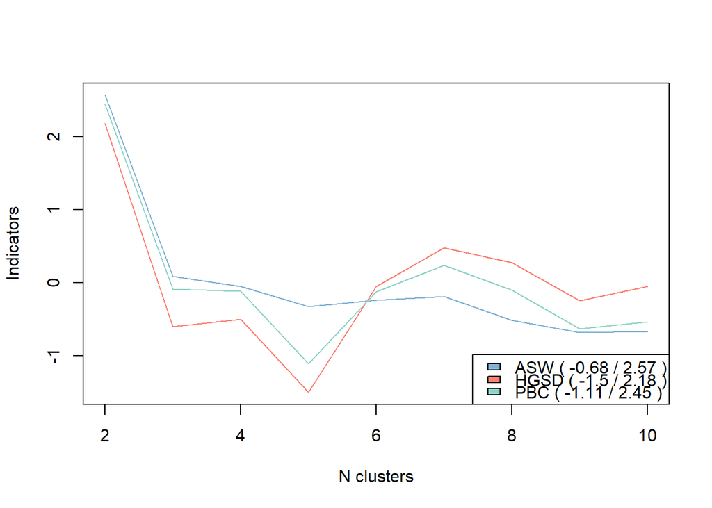

```r
#graph to show empirical fit of cluster solutions
windows()

plot(wardrange.OM, stat=c("ASW", "HGSD", "PBC"), norm="zscore")
```

We seek to determine the optimal number of clusters k. We use a range of empirical metrics to assist with this exercise, however, the optimal number of clusters is better determined by the user given the context and use case. It is an art. There is no wrong or right answer!

As can be seen from the results below from the average silhouette score, two clusters is suggested as the optimal solution. However, we could argue that we gain very little from such coarse partition of the data. We suggest to take this as guidance and a starting point to look to identify an appropriate data partition. We suggest to visualise different solution and gain an understanding of what data get split and decide on whether the resulting patterns contribute to the understanding of the process at hand.

```r
clusters.7 <- cutree(clusterward, k = 7)
cluster <- factor(clusters.7, labels = paste("Type", 1:7))
```

## Stage 4 - Visualisation

Our final stage involves visualising our trajectory clusters to understand the patterns captured in our sequence and cluster analysis. As before, we create two different sequence plots; index and distribution plots. Both are essential for understanding the population processes depicted in each cluster.

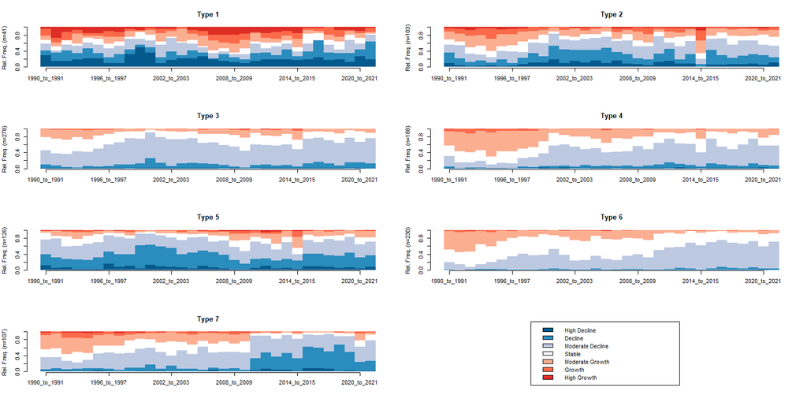

Distribution Plot

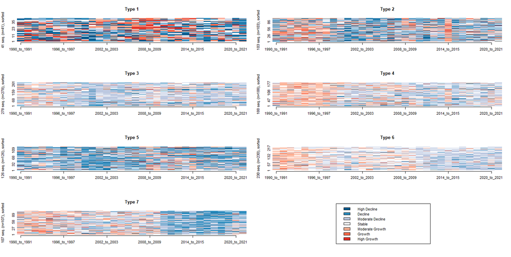

Index Plot

```r
#state index and state distribution plots by cluster
windows()
seqIplot(seq_all, group = cluster, border = NA, sortv= dist.dhd)
seqdplot(seq_all, group = cluster, border = NA)
```